# Johns Hopkins Coursera - Statistical Inference - Project Part 2

shostiou

06/09/2020

## Part 02 - Basic Inferential Data Analysis

This second part of the project is dedicated to the analysis of the ToothGrowth dataset (embedded in the R package).

### Data upload & basic exploration

Let’s start by loading the dataset and by doing basic explorations.  
Refering to the help associated to the data, this dataset is describe as : **“The response is the length of odontoblasts (cells responsible for tooth growth) in 60 guinea pigs. Each animal received one of three dose levels of vitamin C (0.5, 1, and 2 mg/day) by one of two delivery methods, orange juice or ascorbic acid (a form of vitamin C and coded as VC).”**

Content :  
60 observations on 3 variables. [,1] len numeric Tooth length [,2] supp factor Supplement type (VC or OJ). [,3] dose numeric Dose in milligrams/day

```r
# Loading the dataset
data(ToothGrowth)
# Getting general overview of the data
str(ToothGrowth)
```

```
## 'data.frame':    60 obs. of  3 variables:
##  $ len : num  4.2 11.5 7.3 5.8 6.4 10 11.2 11.2 5.2 7 ...
##  $ supp: Factor w/ 2 levels "OJ","VC": 2 2 2 2 2 2 2 2 2 2 ...
##  $ dose: num  0.5 0.5 0.5 0.5 0.5 0.5 0.5 0.5 0.5 0.5 ...
```

```r
# Getting summary statistics.
summary(ToothGrowth)
```

```
##       len        supp         dose
##  Min.   : 4.20   OJ:30   Min.   :0.500
##  1st Qu.:13.07   VC:30   1st Qu.:0.500
##  Median :19.25           Median :1.000
##  Mean   :18.81           Mean   :1.167
##  3rd Qu.:25.27           3rd Qu.:2.000
##  Max.   :33.90           Max.   :2.000
```

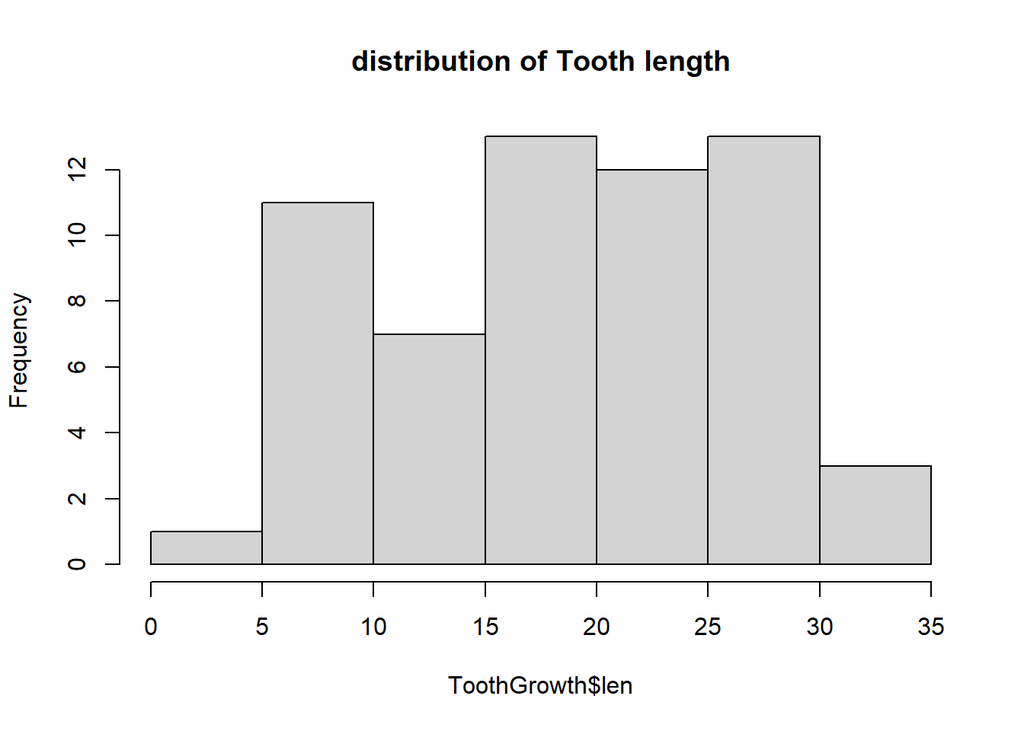

```r
# Let's visualize the distribution of the numerical values
hist(ToothGrowth$len, main = "distribution of Tooth length")
```

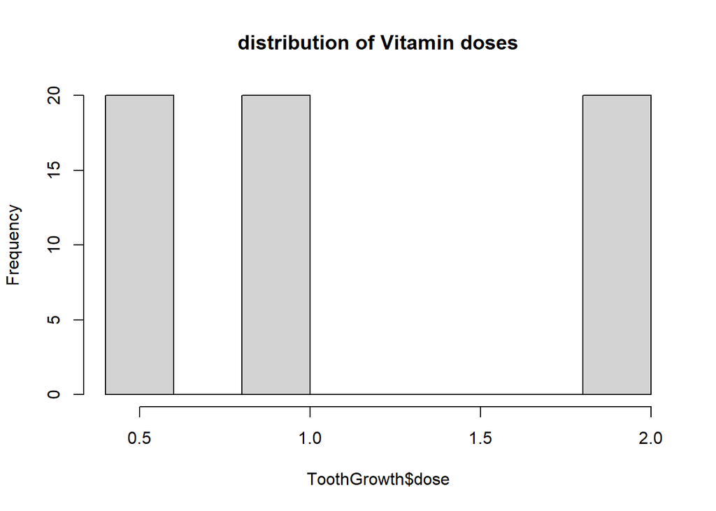

```r
hist(ToothGrowth$dose, main = "distribution of Vitamin doses")
```

```r
# Nb of rows
df_nb_rows = as.numeric(nrow(ToothGrowth))
```

We can observe that the data contains 2 groups of observations. Each of those groups is made of 30 observation (Orange Juice / Ascorbic Acid).  
Even though the vitamin doses is numerical data, the values observed in the dataset is limited to 3 levels : 0.5; 1 ; 2. We can consider this variable as a discrete (not coninuous).

Let’s pursue the exploration by comparing the distribution of Tooth length based on the delivery method used (orange Juice - OJ ; ascorbid acid - VC)

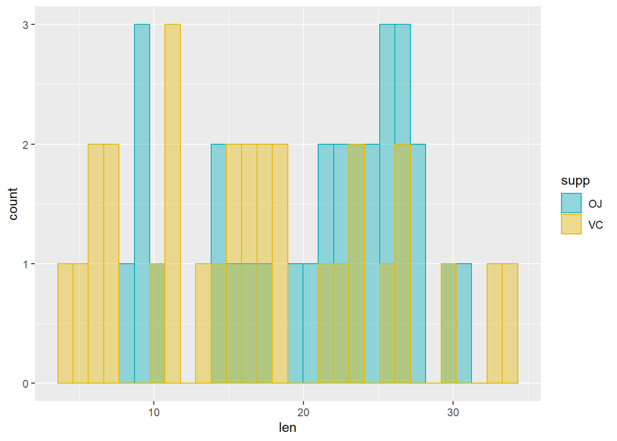

```r
# We call use ggplot2 to show the distributions
library(ggplot2)
# Building the histograms based on supp variable
ggplot(ToothGrowth, aes(x = len)) +
  geom_histogram(aes(color = supp, fill = supp),
                position = "identity", alpha = 0.4) +
  scale_color_manual(values = c("#00AFBB", "#E7B800")) +
  scale_fill_manual(values = c("#00AFBB", "#E7B800"))
```

The observation of the 2 overlapped distributions doesn’t provide a key evidence between Tooth lengths & the delivery method used during the experiment.

### Comparing the means

Let’s compare the means of the tooth length distribution based on the delivery method.

```r
# Let's call the dplyr package
library(dplyr)
# means & standard error computation
ToothGrowth %>% group_by(supp) %>% summarize(mean_len = mean(len), std_len = sd(len))
```

```
## # A tibble: 2 x 3
##   supp  mean_len std_len
##   <fct>    <dbl>   <dbl>
## 1 OJ        20.7    6.61
## 2 VC        17.0    8.27
```

We can observe that mean values of the 2 distributions (tooth length with orange juice OJ / tooth length with ascorbic acis CV) differs.

### Hypothesis Test

Finally we will conclude the hypothesis test by computing the p-value associated to a confidence interval of 95%. The test to be used will be 2 sided test. Note : a two tail test will be used.  
Let’s use T distribution to calculate the p-value.

```r
# Let's define specific dataframes for OJ and VC
len_OJ <- ToothGrowth %>% filter(supp == 'OJ') %>% select(len)
len_VC <- ToothGrowth %>% filter(supp == 'VC') %>% select(len)
# Applying the T test using the R native command
t.test(len_OJ,len_VC, alternative="two.sided", paired=FALSE, mu = 0, conf.level = 0.95)
```

```
##
##  Welch Two Sample t-test
##
## data:  len_OJ and len_VC
## t = 1.9153, df = 55.309, p-value = 0.06063
## alternative hypothesis: true difference in means is not equal to 0
## 95 percent confidence interval:
##  -0.1710156  7.5710156
## sample estimates:
## mean of x mean of y
##  20.66333  16.96333
```

**CONCLUSION :** as p-value > 0.05 we failed to reject the null hypothesis.  
The data doesn’t provide evidence of differences in means between the Orange Juice and Ascorbic Acid feeding methods.